# Stats2 Project 1

### CAtBat

CAtBat Number of times at bat during his career

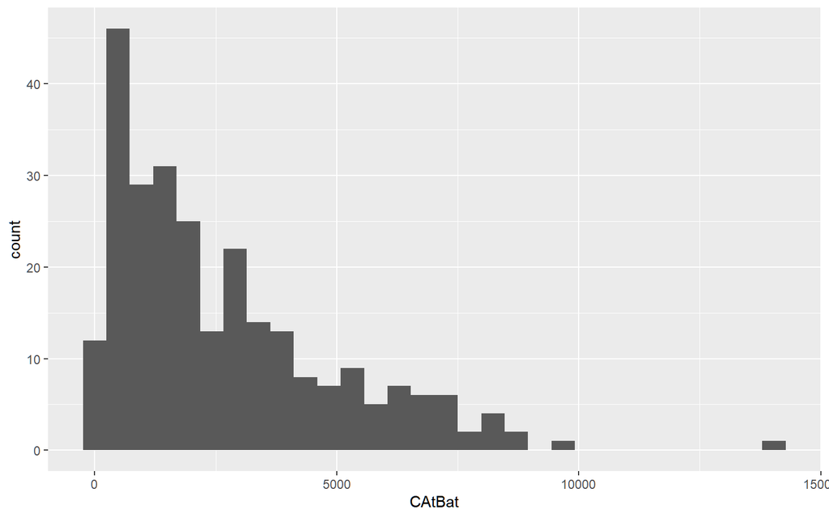

```r
histPlot(x = "CAtBat")
```

```r
summary(hitters$CAtBat)
```

```
   Min. 1st Qu.  Median    Mean 3rd Qu.    Max.
   19.0   842.5  1931.0  2657.5  3890.5 14053.0
```

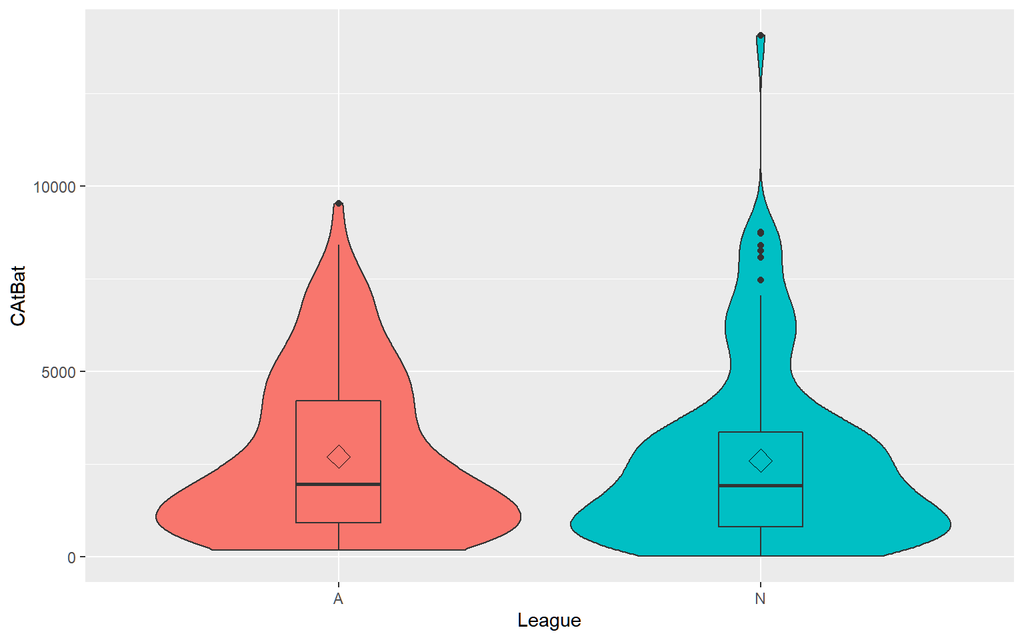

```r
vioPlot(x = "League", y = "CAtBat")
```

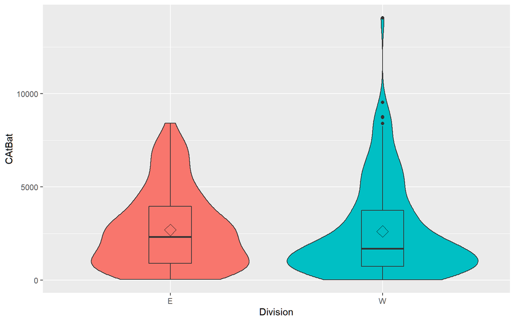

```r
vioPlot(x = "Division", y = "CAtBat")
```

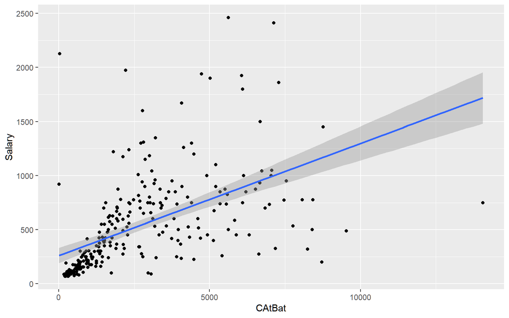

```r
scatterPlot(x = "CAtBat")
```

### CHits

CHits Number of hits during his career

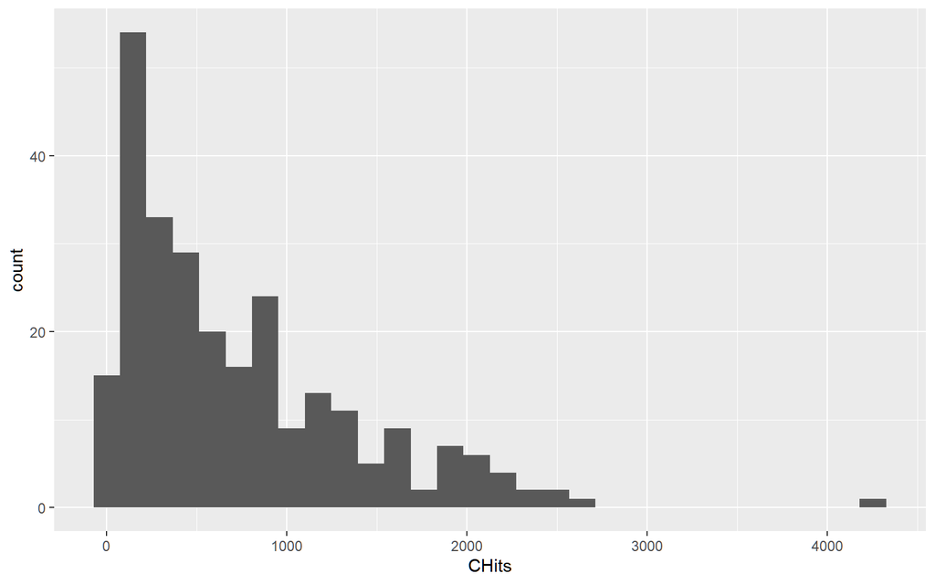

```r
histPlot(x = "CHits")
```

```r
summary(hitters$CHits)
```

```
   Min. 1st Qu.  Median    Mean 3rd Qu.    Max.
    4.0   212.0   516.0   722.2  1054.0  4256.0
```

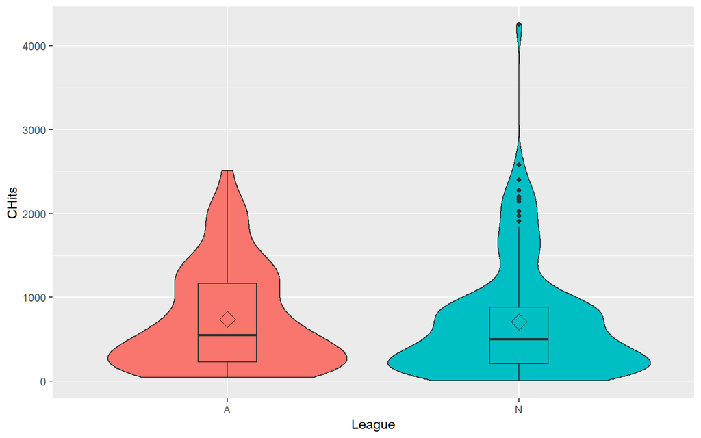

```r
vioPlot(x = "League", y = "CHits")
```

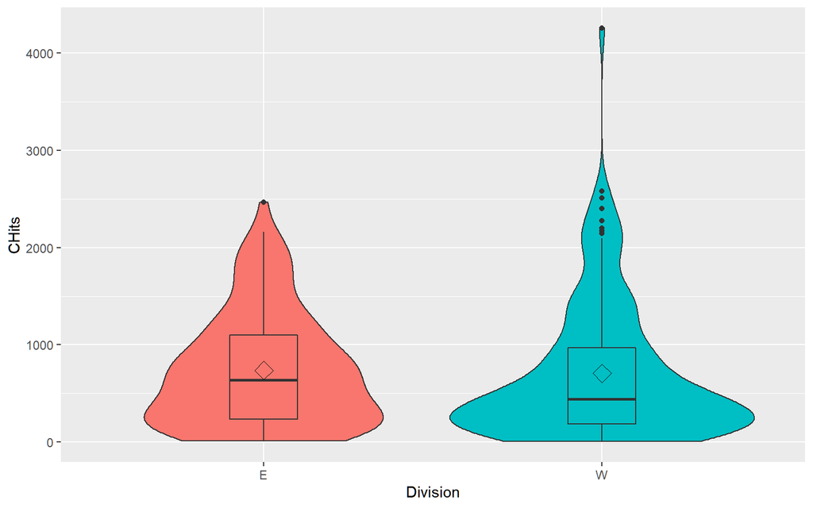

```r
vioPlot(x = "Division", y = "CHits")
```

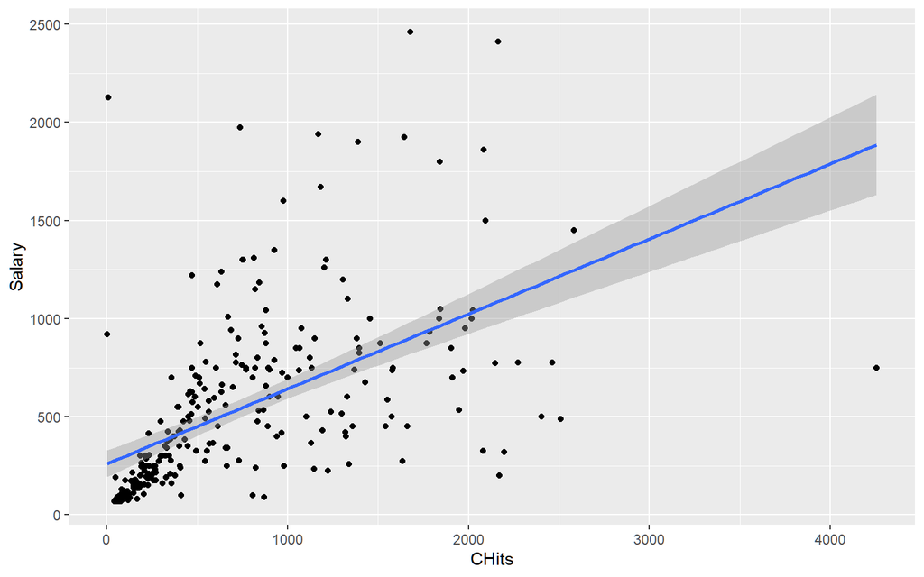

```r
scatterPlot(x = "CHits")
```

### CHmRun

CHmRun Number of home runs during his career

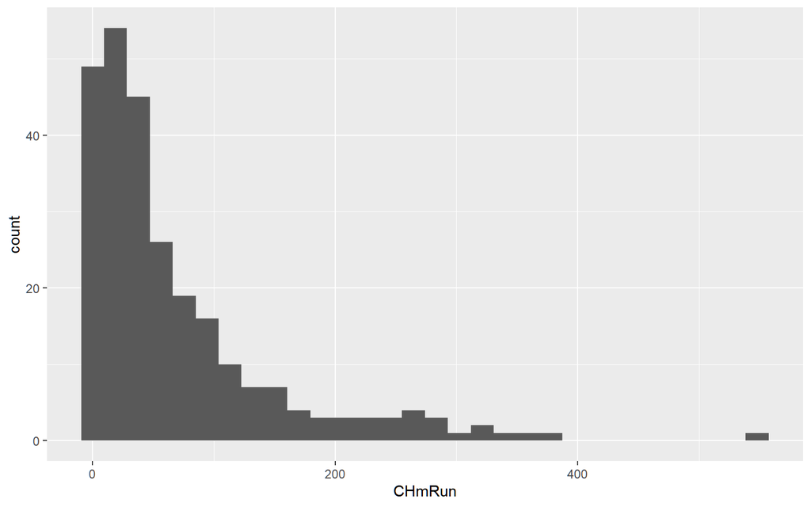

```r
histPlot(x = "CHmRun")
```

```r
summary(hitters$CHmRun)
```

```
   Min. 1st Qu.  Median    Mean 3rd Qu.    Max.
   0.00   15.00   40.00   69.24   92.50  548.00
```

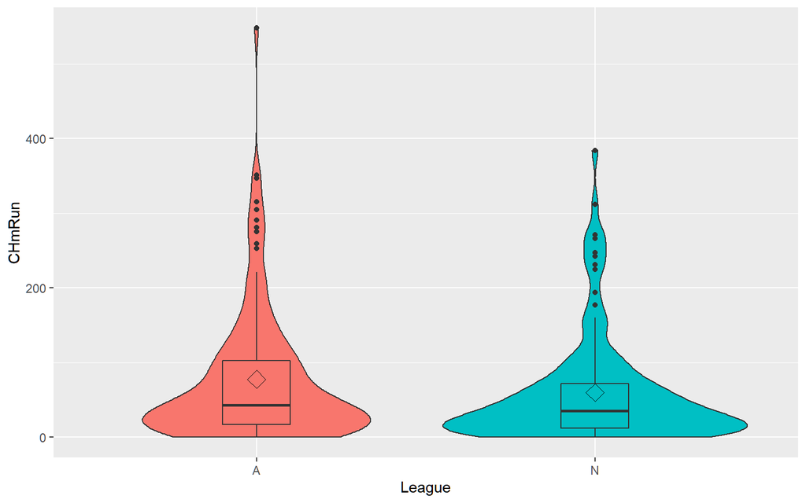

```r
vioPlot(x = "League", y = "CHmRun")
```

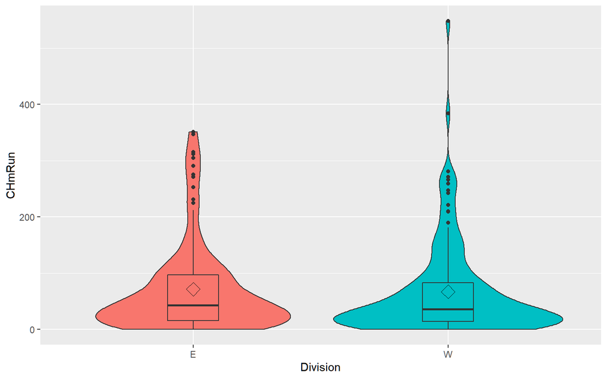

```r
vioPlot(x = "Division", y = "CHmRun")
```

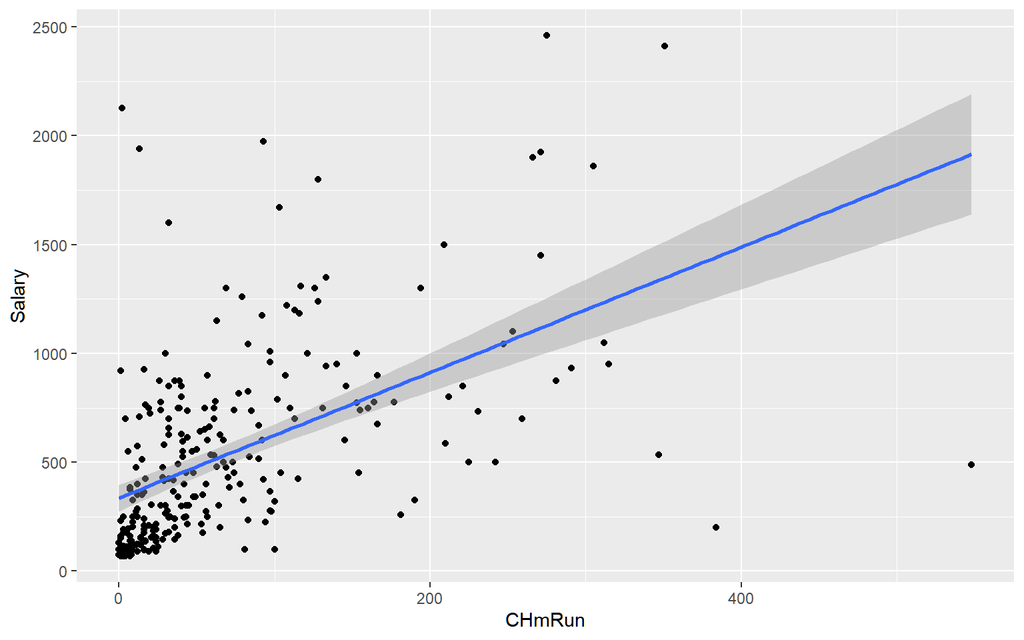

```r
scatterPlot(x = "CHmRun")
```

### CRuns

CRuns Number of runs during his career

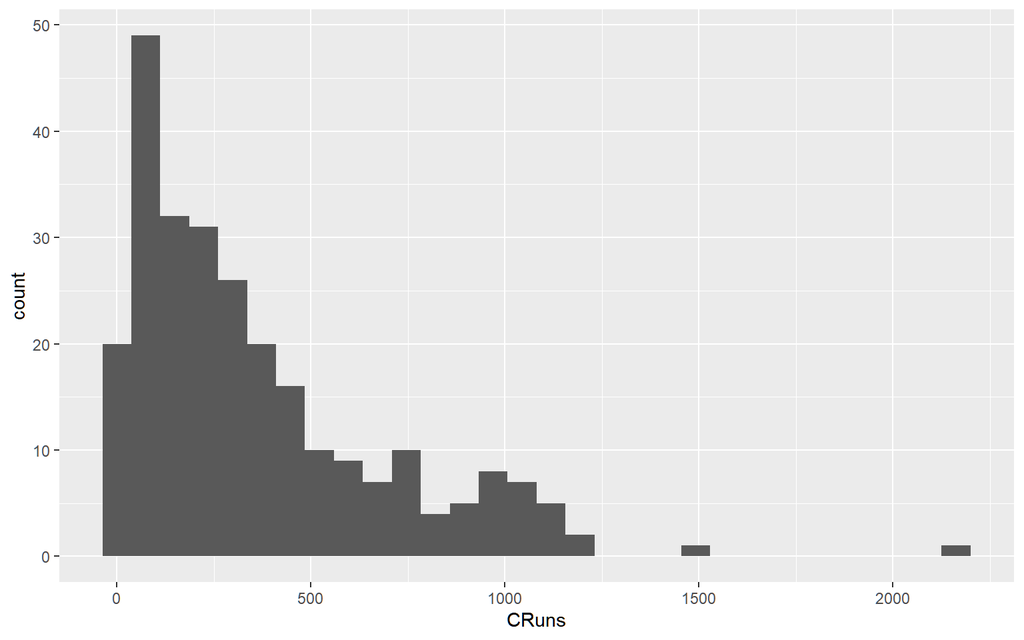

```r
histPlot(x = "CRuns")
```

```r
summary(hitters$CRuns)
```

```
   Min. 1st Qu.  Median    Mean 3rd Qu.    Max.
    2.0   105.5   250.0   361.2   497.5  2165.0
```

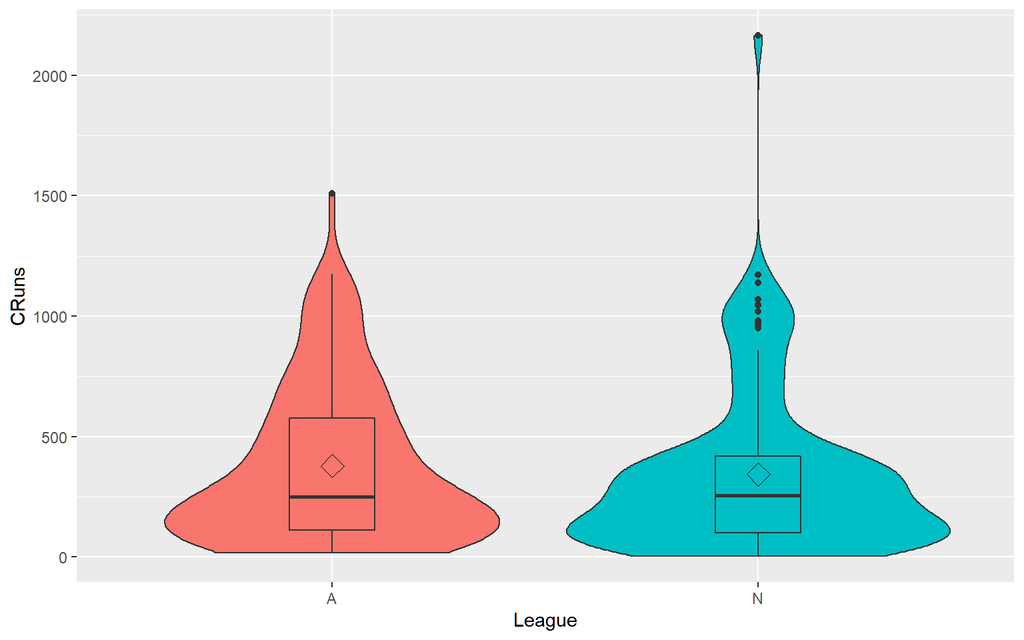

```r
vioPlot(x = "League", y = "CRuns")
```

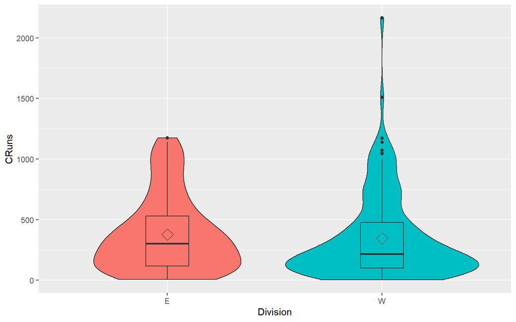

```r
vioPlot(x = "Division", y = "CRuns")
```

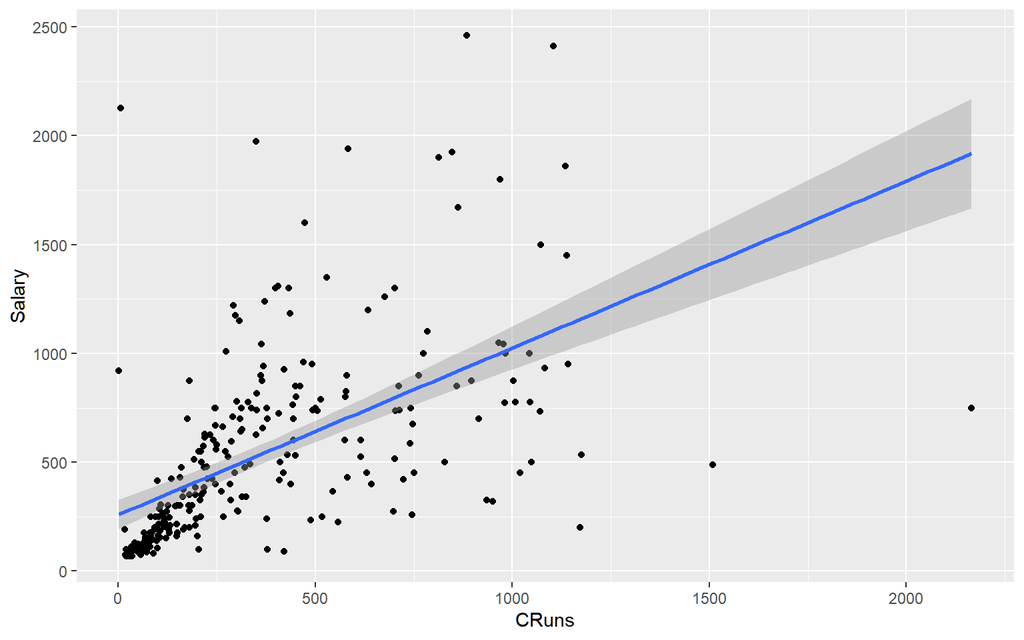

```r
scatterPlot(x = "CRuns")
```

### CRBI

CRBI Number of runs batted in during his career

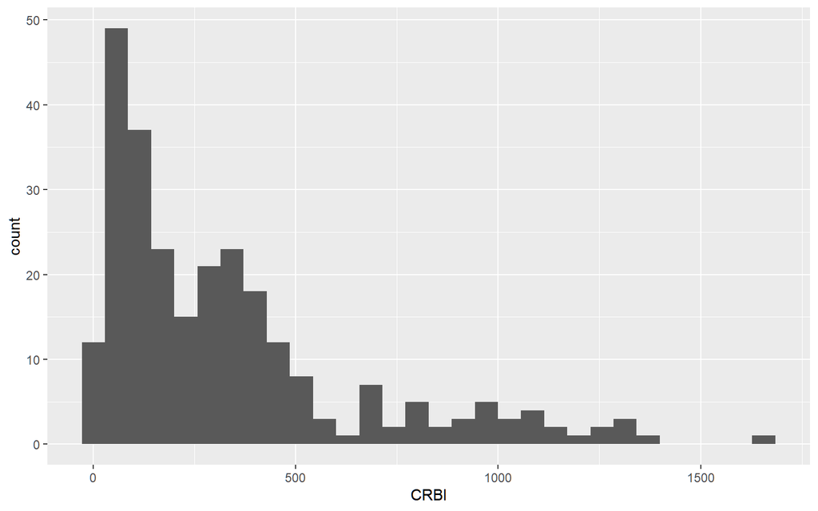

```r
histPlot(x = "CRBI")
```

```r
summary(hitters$CRBI)
```

```
   Min. 1st Qu.  Median    Mean 3rd Qu.    Max.
    3.0    95.0   230.0   330.4   424.5  1659.0
```

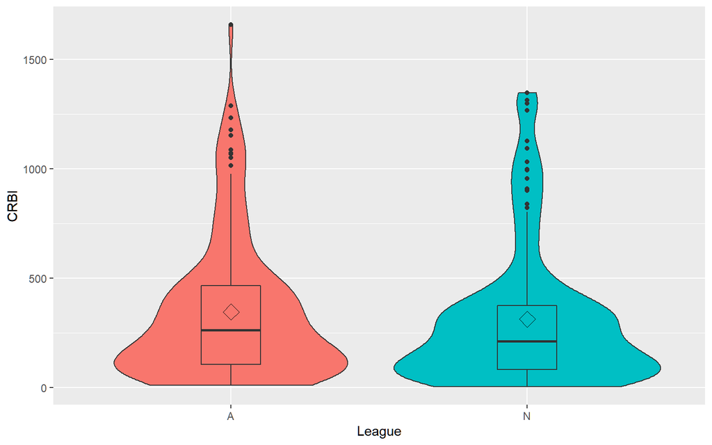

```r
vioPlot(x = "League", y = "CRBI")
```

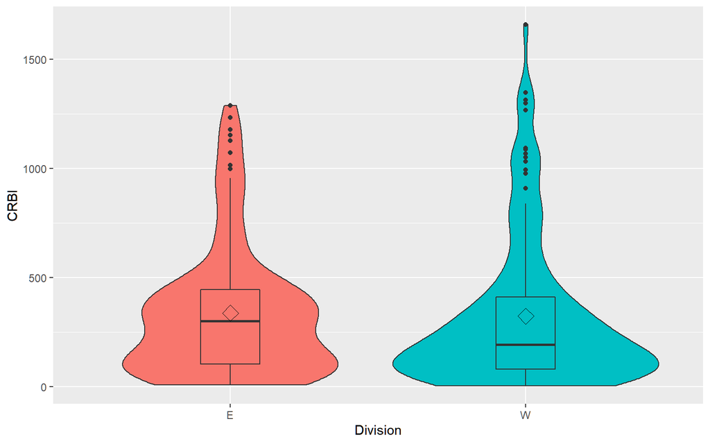

```r
vioPlot(x = "Division", y = "CRBI")
```

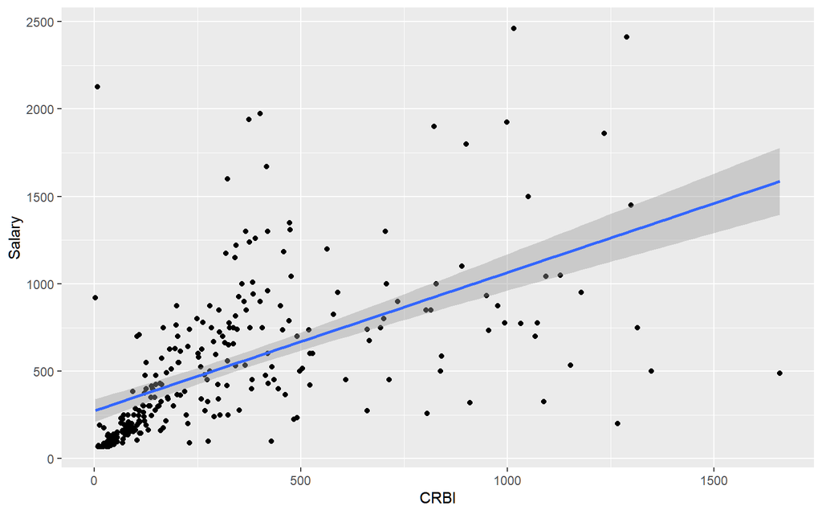

```r
scatterPlot(x = "CRBI")
```

### CWalks

CWalks Number of walks during his career

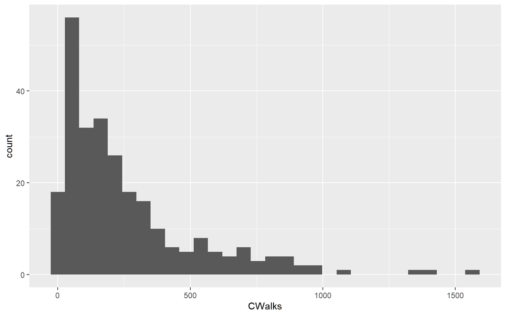

```r
histPlot(x = "CWalks")
```

```r
summary(hitters$CWalks)
```

```
   Min. 1st Qu.  Median    Mean 3rd Qu.    Max.
    1.0    71.0   174.0   260.3   328.5  1566.0
```

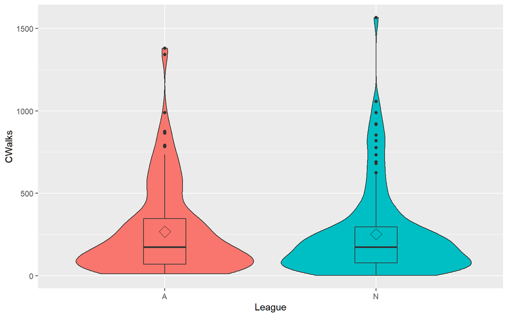

```r
vioPlot(x = "League", y = "CWalks")
```

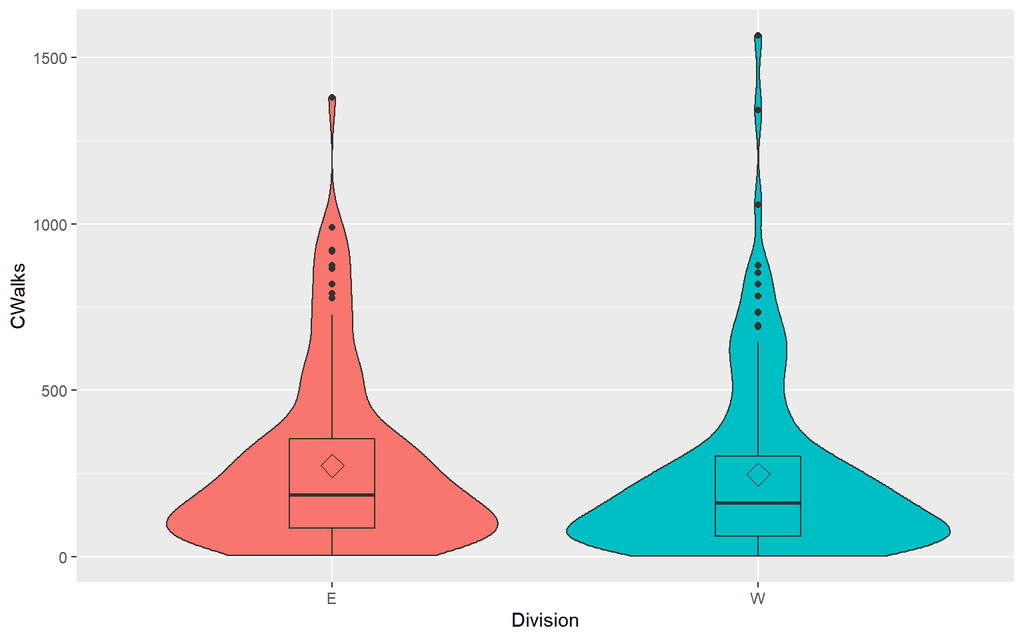

```r
vioPlot(x = "Division", y = "CWalks")
```

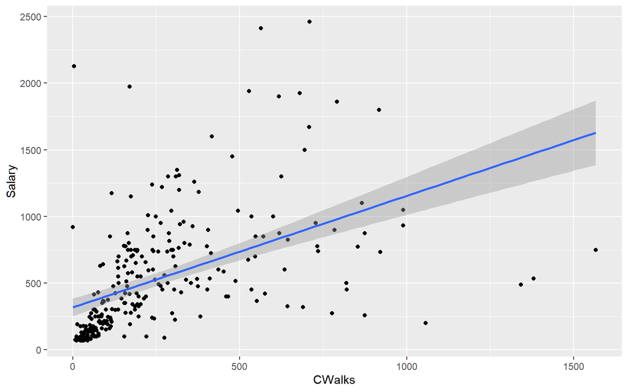

```r
scatterPlot(x = "CWalks")
```

### PutOuts

PutOuts Number of put outs in 1986

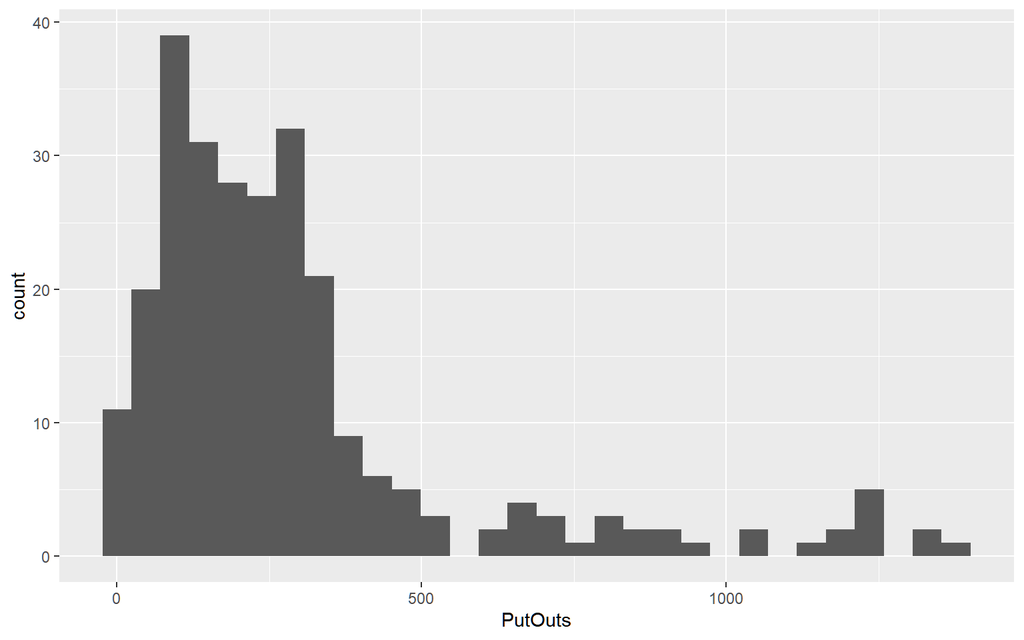

```r
histPlot(x = "PutOuts")
```

```r
summary(hitters$PutOuts)
```

```
   Min. 1st Qu.  Median    Mean 3rd Qu.    Max.
    0.0   113.5   224.0   290.7   322.5  1377.0
```

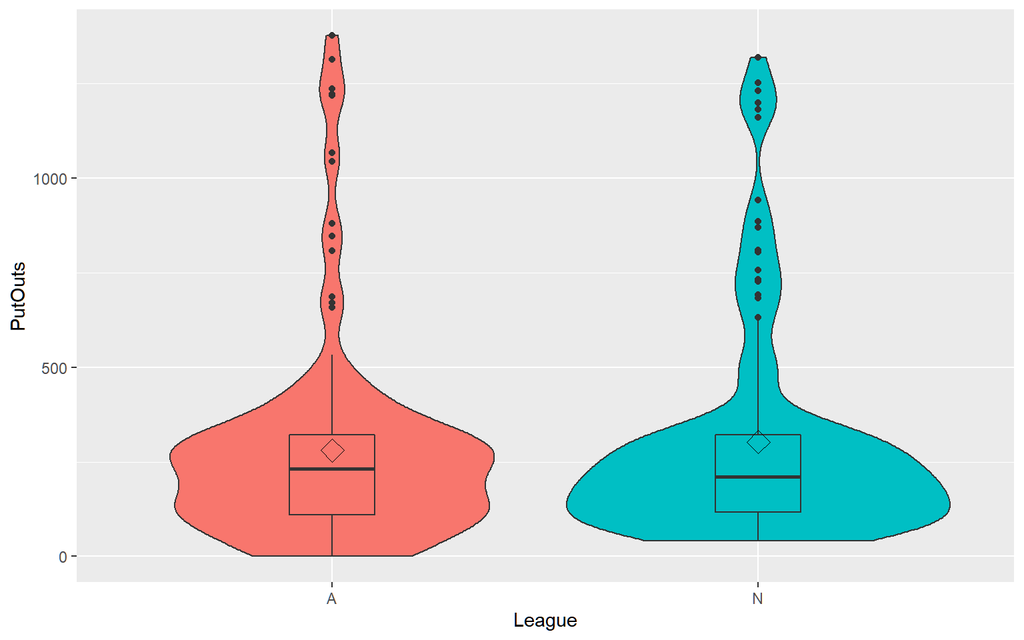

```r
vioPlot(x = "League", y = "PutOuts")
```

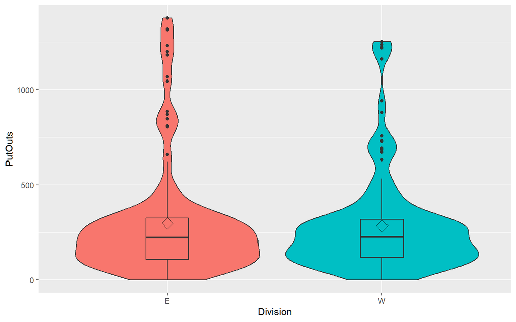

```r
vioPlot(x = "Division", y = "PutOuts")
```

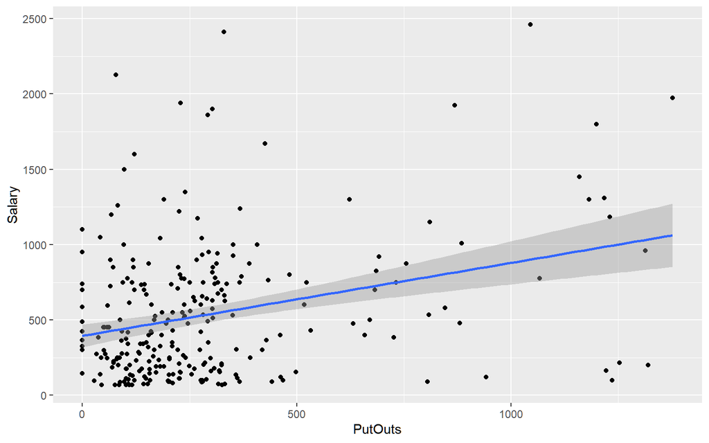

```r
scatterPlot(x = "PutOuts")
```

### Assists

Assists Number of assists in 1986

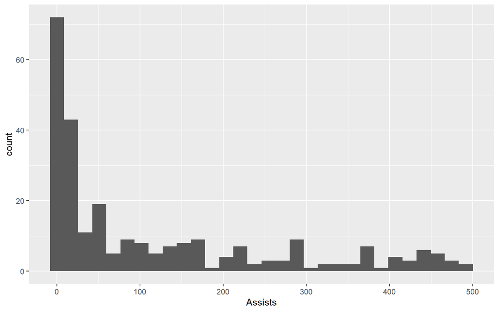

```r
histPlot(x = "Assists")
```

```r
summary(hitters$Assists)
```

```
   Min. 1st Qu.  Median    Mean 3rd Qu.    Max.
    0.0     8.0    45.0   118.8   192.0   492.0
```

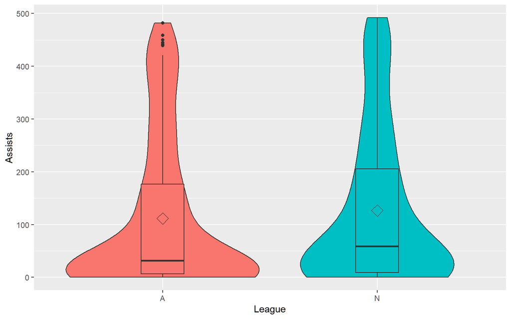

```r
vioPlot(x = "League", y = "Assists")
```

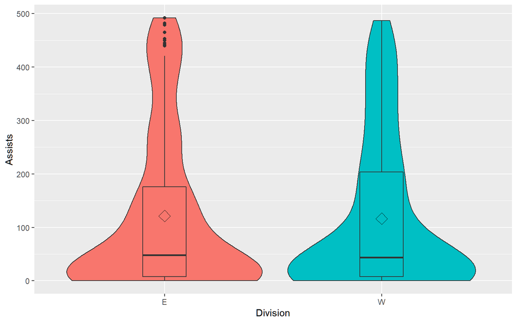

```r
vioPlot(x = "Division", y = "Assists")
```

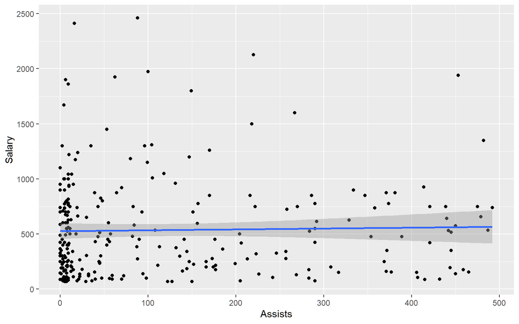

```r
scatterPlot(x = "Assists")
```

### Errors

Errors Number of errors in 1986

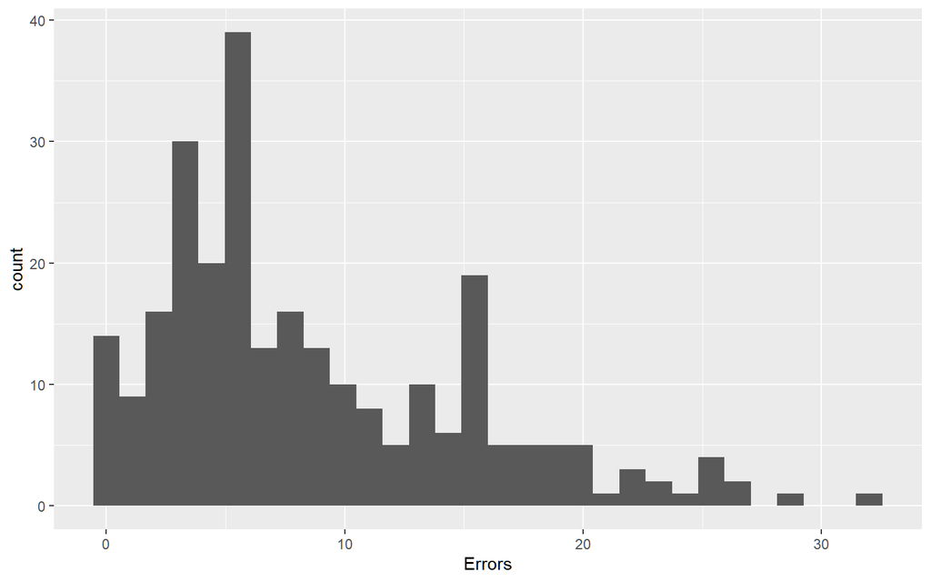

```r
histPlot(x = "Errors")
```

```r
summary(hitters$Errors)
```

```
   Min. 1st Qu.  Median    Mean 3rd Qu.    Max.
  0.000   3.000   7.000   8.593  13.000  32.000
```

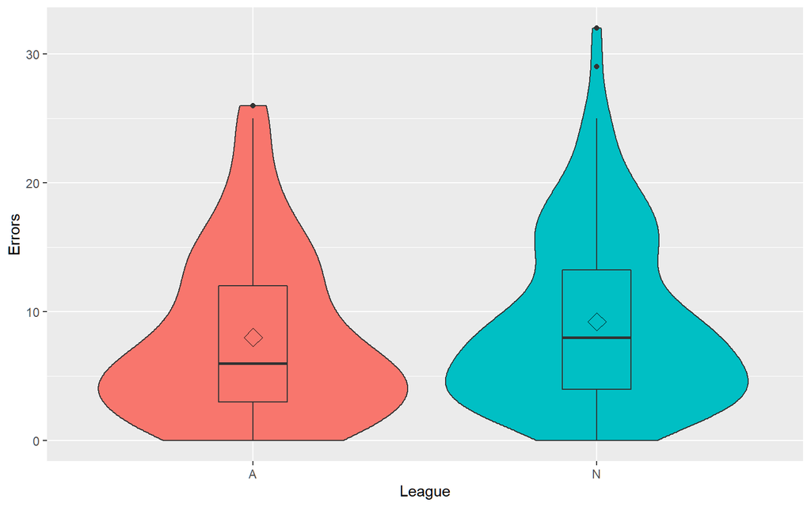

```r
vioPlot(x = "League", y = "Errors")
```

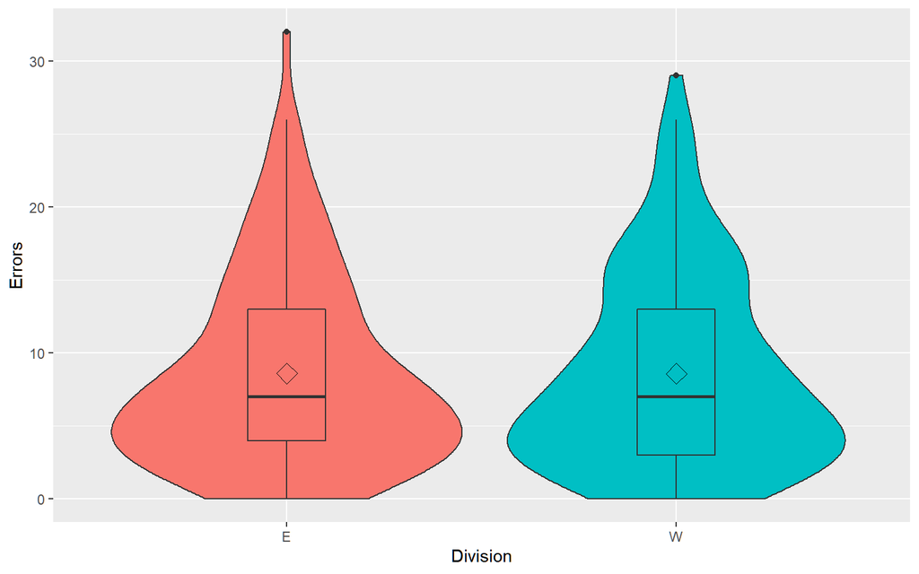

```r
vioPlot(x = "Division", y = "Errors")
```

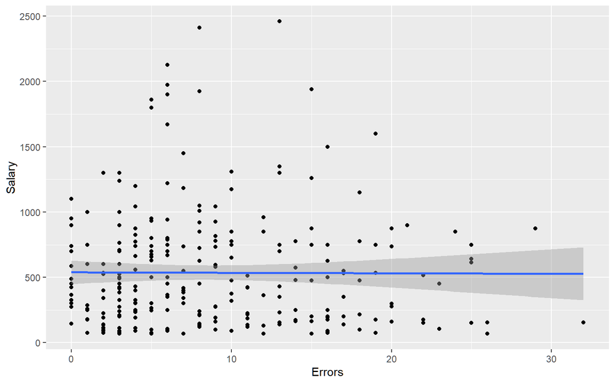

```r
scatterPlot(x = "Errors")
```

### League

League A factor with levels A and N indicating player’s league at the end of 1986

```r
fancyTable(x = "League")
```

| League | Count | Proportion |
| --- | --- | --- |
| A | 139 | 52.9% |
| N | 124 | 47.1% |

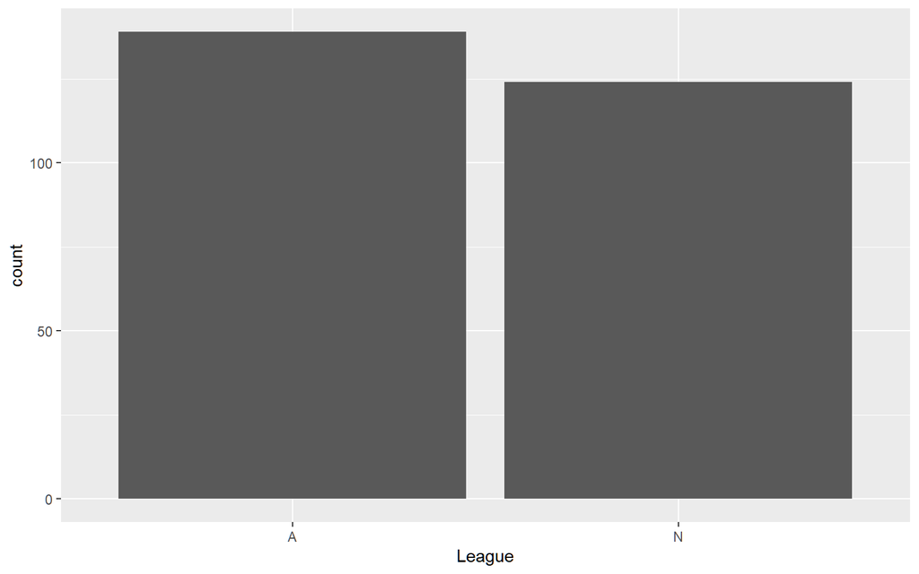

```r
barPlot(x = "League")
```

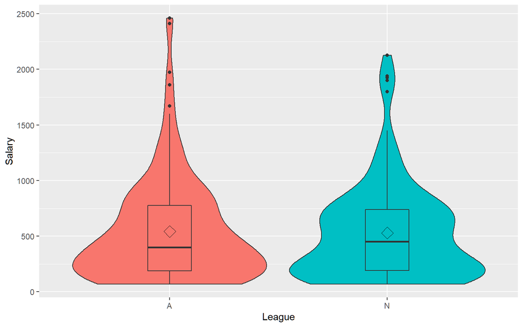

```r
vioPlot(x = "League", y = "Salary")
```

### Division

Division A factor with levels E and W indicating player’s division at the end of 1986

```r
fancyTable(x = "Division")
```

| Division | Count | Proportion |
| --- | --- | --- |
| E | 129 | 49.0% |
| W | 134 | 51.0% |

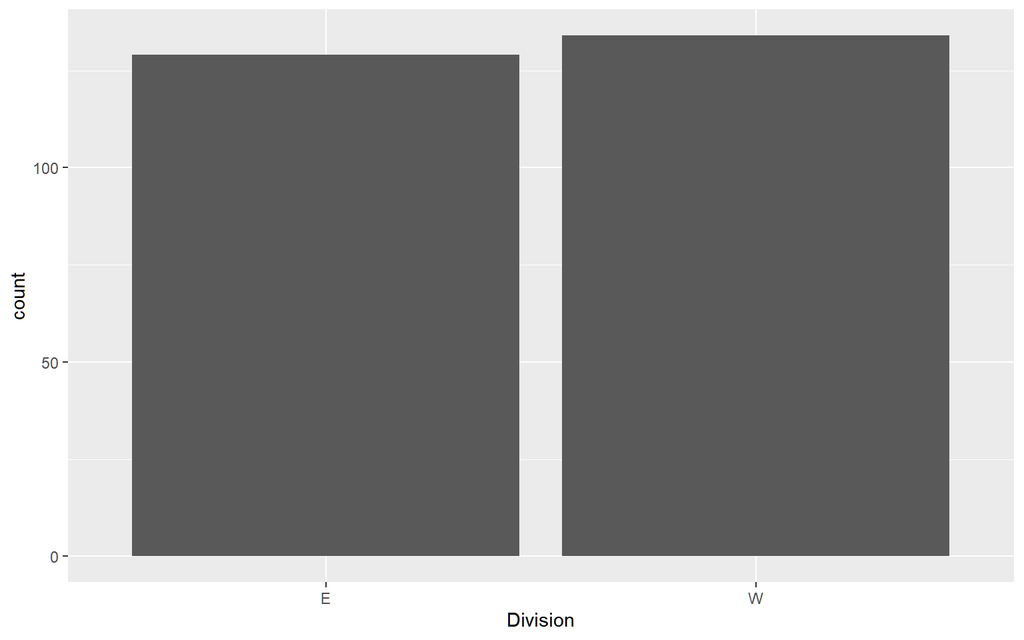

```r
barPlot(x = "Division")
```

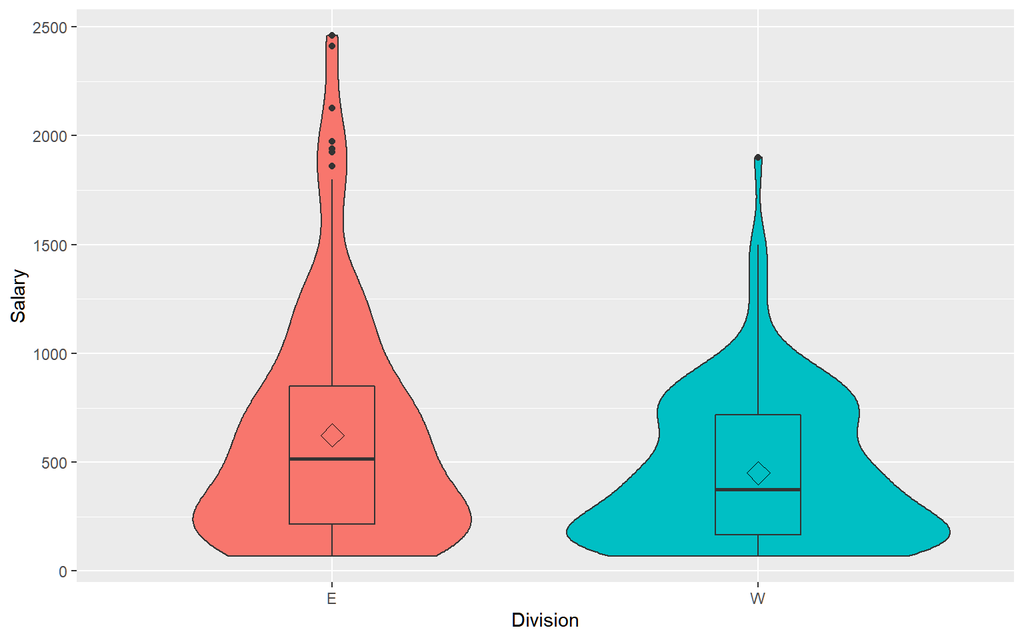

```r
vioPlot(x = "Division", y = "Salary")
```

### NewLeague

NewLeague A factor with levels A and N indicating player’s league at the beginning of 1987

```r
fancyTable(x = "NewLeague")
```

| NewLeague | Count | Proportion |
| --- | --- | --- |
| A | 141 | 53.6% |
| N | 122 | 46.4% |

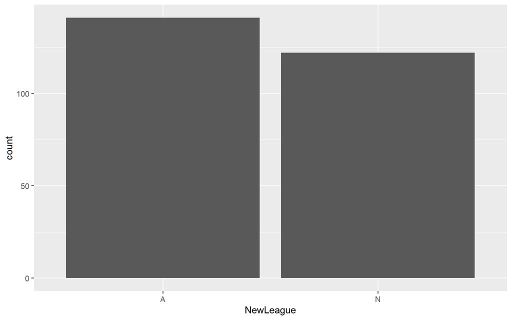

```r
barPlot(x = "NewLeague")
```

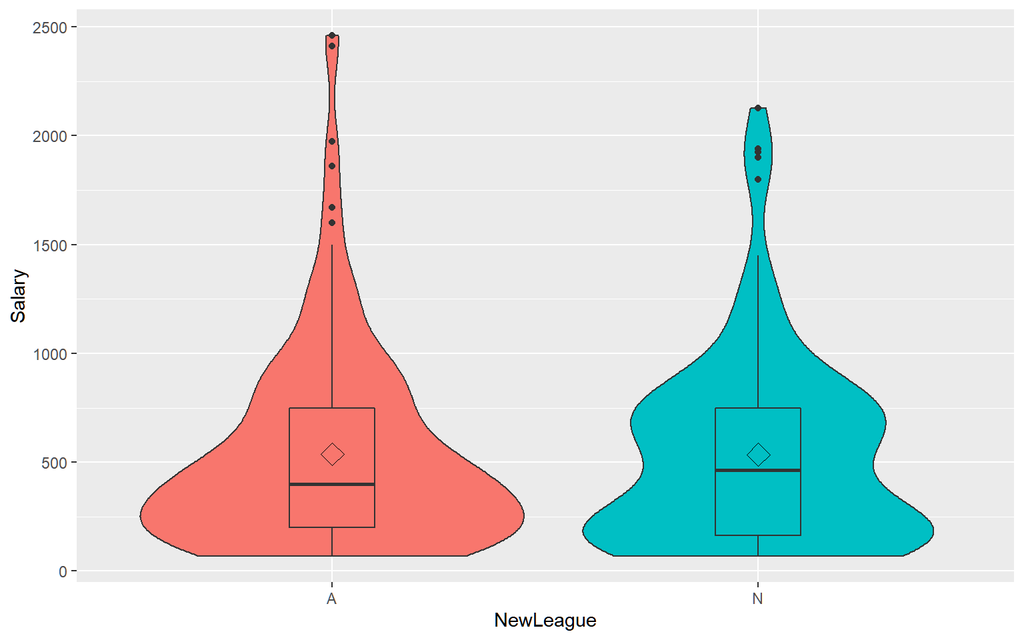

```r
vioPlot(x = "NewLeague", y = "Salary")
```

### Correlation Plot

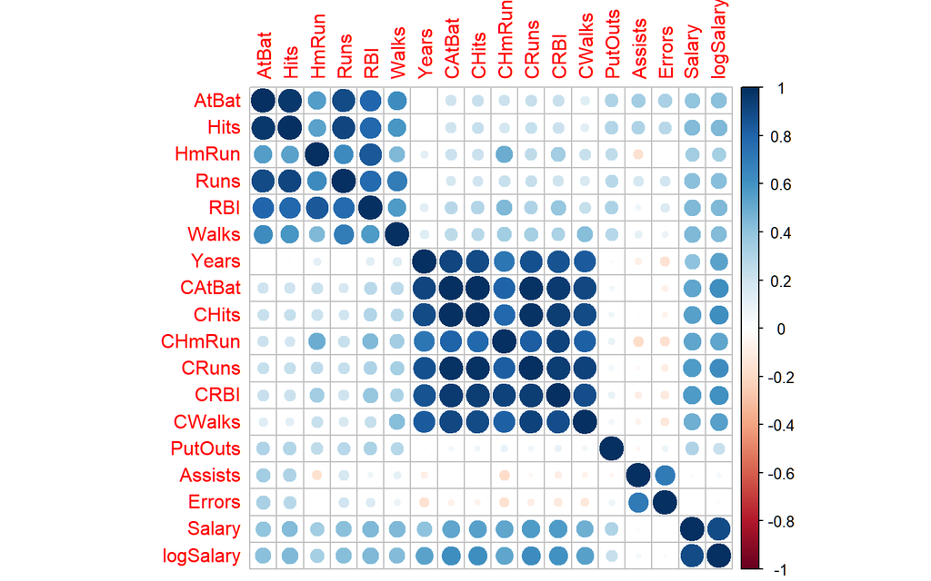

```r
library(GGally)
# ggpairs(data = hitters, mapping = aes(color = League), columns =
# c('Salary','AtBat','Hits','HmRun','Runs','RBI','Walks','Years',
# 'CAtBat','CHits','CHmRun','CRuns','CRBI','CWalks','PutOuts',
# 'Assists','Errors'))

# ggpairs(data = hitters, mapping = aes(color = League), columns =
# c('Salary','CAtBat','CHits','CHmRun','CRuns','CRBI','CWalks','PutOuts',
# 'Assists','Errors')) ggpairs(data = hitters, mapping = aes(color =
# League), columns =
# c('Salary','AtBat','Hits','HmRun','Runs','RBI','Walks','Years'))

library(corrplot)
cors <- cor(hitters %>% keep(is.numeric))
corrplot(cors, method = "circle")
```

## LASSO Selecction

```r
library(caret)
lambda <- 10^seq(-3, 3, length = 100)
set.seed(314159)

lasso <- train(logSalary ~ ., data = hitters %>% select(-Salary), method = "glmnet",
    trControl = trainControl("cv", number = 5), tuneGrid = expand.grid(alpha = 1,
        lambda = lambda))
# Model coefficients
coef(lasso$finalModel, lasso$bestTune$lambda)
```

```
20 x 1 sparse Matrix of class "dgCMatrix"
                        1
(Intercept)  4.5770009946
AtBat       -0.0017540385
Hits         0.0091170410
HmRun        0.0067309586
Runs         0.0002657268
RBI          .
Walks        0.0081937014
Years        0.0565445812
CAtBat       .
CHits        0.0001956080
CHmRun       0.0001650749
CRuns        0.0007653354
CRBI         .
CWalks      -0.0008179483
LeagueN      0.2354777679
DivisionW   -0.1622166376
PutOuts      0.0003024935
Assists      0.0004636276
Errors      -0.0109878888
NewLeagueN  -0.1318243168
```

```r
# Make predictions
predictions <- lasso %>% predict(hitters)
# Model prediction performance
perf <- data.frame(RMSE = RMSE(exp(predictions), hitters$Salary), Rsquare = R2(exp(predictions),
    hitters$Salary))
```

## LASSO Selection 2

As mentioned above, we see some justification for logging Salary. Additionally, there is benefit to logging the career attributes as well, those the start with ‘C’. Let’s compare before and after scatter plots.

- Scatter plots using Salary

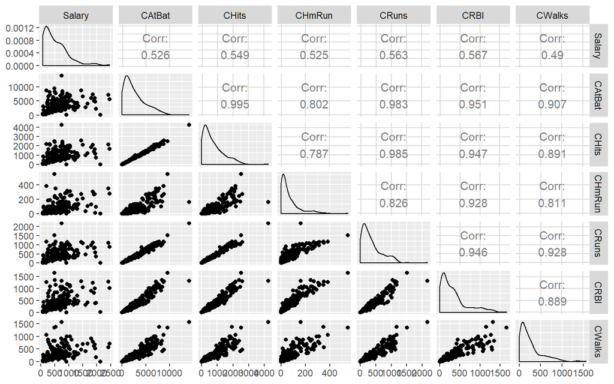

```r
ggpairs(data = hitters, columns = c("Salary", "CAtBat", "CHits", "CHmRun", "CRuns",
    "CRBI", "CWalks"))
```

- Scatter plots using log of Salary

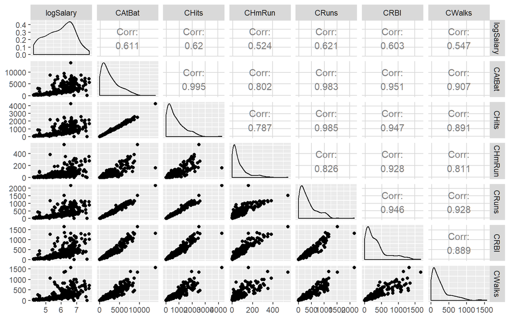

```r
ggpairs(data = hitters, columns = c("logSalary", "CAtBat", "CHits", "CHmRun",
    "CRuns", "CRBI", "CWalks"))
```

- Scatter plots using log of Salary and log of Career Attributes. Important, I’m adding 1 to the log to avoid 0s/NAs.

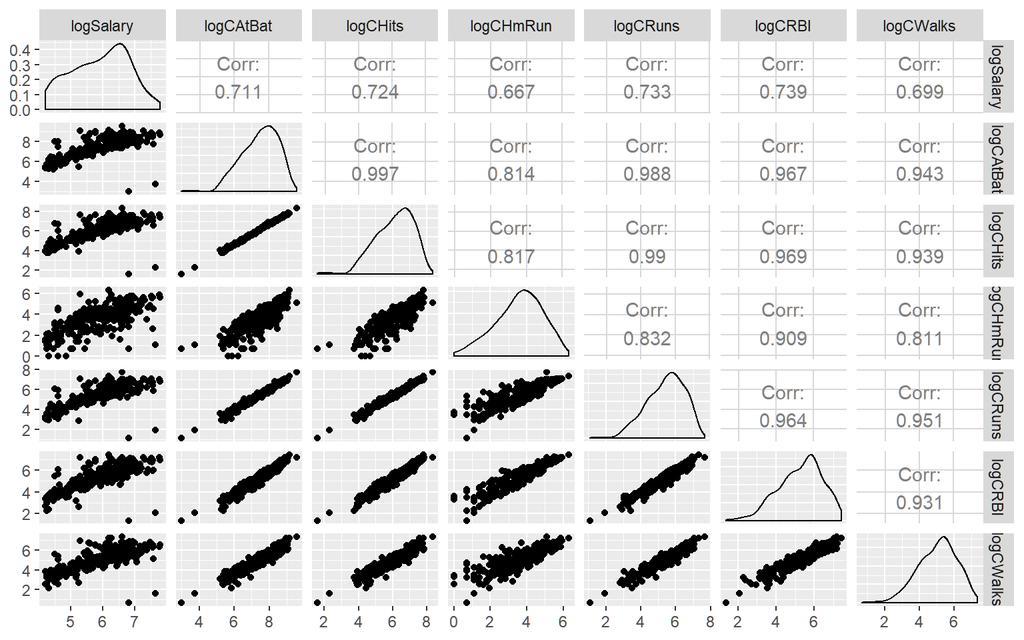

```r
hitters$logCAtBat <- log(hitters$CAtBat + 1)
hitters$logCHits <- log(hitters$CHits + 1)
hitters$logCHmRun <- log(hitters$CHmRun + 1)
hitters$logCRuns <- log(hitters$CRuns + 1)
hitters$logCRBI <- log(hitters$CRBI + 1)
hitters$logCWalks <- log(hitters$CWalks + 1)

ggpairs(data = hitters, columns = c("logSalary", "logCAtBat", "logCHits", "logCHmRun",
    "logCRuns", "logCRBI", "logCWalks"))
```

Above we can see that the correlation is stronger with the 3rd plot and we generally see a better linear fit.

*Linear Model Selection*

With regards to model selection, our first attempt was to use Lasso, since it’s generally regarded as being better than forward/backward/stepwise selection. Ridge is also another possibility, but it will include all predictors in the model. Ridge and Lasso are techniques that shrink the coefficient estimates to zero, include a tuning parameter and shrinkage penalty. Additionally, Ridge and Lasso are computationally less expensive than forward/backward/stepwise. Chapter 6 of ISLR mentioned above has a really good explanation of the different model selection techniques.

```r
# New attempt
library(caret)
library(glmnet)
hittersGlm <- hitters %>% select(-c("Salary", "CAtBat", "CHits", "CHmRun", "CRuns",
    "CRBI", "CWalks"))
set.seed(123)
training.samples <- hittersGlm$logSalary %>% createDataPartition(p = 0.8, list = FALSE)
train.data <- hittersGlm[training.samples, ]
test.data <- hittersGlm[-training.samples, ]

# Predictor variables
x <- model.matrix(logSalary ~ ., train.data)[, -1]
# Outcome variable
y <- train.data$logSalary

# Find the best lambda using cross-validation
set.seed(123)
cv <- cv.glmnet(x, y, alpha = 0)

# Display the best lambda value
cv$lambda.min

# Fit the final model on the training data
modelRidge <- glmnet(x, y, alpha = 0, lambda = cv$lambda.min)

# Display regression coefficients
coef(modelRidge)

# Make predictions on the test data
x.test <- model.matrix(logSalary ~ ., test.data)[, -1]
predictions <- modelRidge %>% predict(x.test) %>% as.vector()
# Model performance metrics
metricsRidge <- data.frame(RMSERidge = RMSE(predictions, test.data$logSalary),
    RsquareRidge = R2(predictions, test.data$logSalary))


# LASSO Find the best lambda using cross-validation Note that alpha = 1 here
set.seed(123)
cv <- cv.glmnet(x, y, alpha = 1)

# Display the best lambda value
cv$lambda.min

# Fit the final model on the training data
modelLasso <- glmnet(x, y, alpha = 1, lambda = cv$lambda.min)

# Dsiplay regression coefficients
coef(modelLasso)

# Make predictions on the test data
x.test <- model.matrix(logSalary ~ ., test.data)[, -1]
predictions <- modelLasso %>% predict(x.test) %>% as.vector()
# Model performance metrics
metricsLasso <- data.frame(RMSE = RMSE(predictions, test.data$logSalary), Rsquare = R2(predictions,
    test.data$logSalary))

# Elastic Ridge Build the model using the training set
set.seed(123)
modelElastic <- train(logSalary ~ ., data = train.data, method = "glmnet", trControl = trainControl("cv",
    number = 10), tuneLength = 10)

# Best tuning parameter
modelElastic$bestTune

# Coefficient of the final model. You need to specify the best lambda
coef(modelElastic$finalModel, modelElastic$bestTune$lambda)

# Make predictions on the test data
x.test <- model.matrix(logSalary ~ ., test.data)[, -1]
predictions <- modelElastic %>% predict(x.test)
# Model performance metrics
metricsElastic <- data.frame(RMSE = RMSE(predictions, test.data$medv), Rsquare = R2(predictions,
    test.data$medv))


### comparison

lambda <- 10^seq(-3, 3, length = 100)

# Least Squares, just set lambda = 0
set.seed(123)
lSquares <- train(logSalary ~ ., data = train.data, method = "glmnet", trControl = trainControl("cv",
    number = 10), tuneGrid = expand.grid(alpha = 0, lambda = 0))
# Model coefficients
coef(lSquares$finalModel, lSquares$bestTune$lambda)
# Make predictions
predictions <- lSquares %>% predict(test.data)
# Model prediction performance
data.frame(RMSE = RMSE(predictions, test.data$logSalary), Rsquare = R2(predictions,
    test.data$logSalary))


# Ridge
set.seed(123)
ridge <- train(logSalary ~ ., data = train.data, method = "glmnet", trControl = trainControl("cv",
    number = 10), tuneGrid = expand.grid(alpha = 0, lambda = lambda))
# Model coefficients
coef(ridge$finalModel, ridge$bestTune$lambda)
# Make predictions
predictions <- ridge %>% predict(test.data)
# Model prediction performance
data.frame(RMSE = RMSE(predictions, test.data$logSalary), Rsquare = R2(predictions,
    test.data$logSalary))

# Build the model
set.seed(123)
lasso <- train(logSalary ~ ., data = train.data, method = "glmnet", trControl = trainControl("cv",
    number = 10), tuneGrid = expand.grid(alpha = 1, lambda = lambda))
# Model coefficients
coef(lasso$finalModel, lasso$bestTune$lambda)
# Make predictions
predictions <- lasso %>% predict(test.data)
# Model prediction performance
data.frame(RMSE = RMSE(predictions, test.data$logSalary), Rsquare = R2(predictions,
    test.data$logSalary))


set.seed(123)
elastic <- train(logSalary ~ ., data = train.data, method = "glmnet", trControl = trainControl("cv",
    number = 10), tuneLength = 10)
# Model coefficients
coef(elastic$finalModel, elastic$bestTune$lambda)
# Make predictions
predictions <- elastic %>% predict(test.data)
# Model prediction performance
data.frame(RMSE = RMSE(predictions, test.data$logSalary), Rsquare = R2(predictions,
    test.data$logSalary))

models <- list(leastSquares = lSquares, ridge = ridge, lasso = lasso, elastic = elastic)
resamples(models) %>% summary(metric = "RMSE")


##############################

# Setup for glmnet
library(caret)
hittersGlm <- hitters %>% select(-c("Salary", "CAtBat", "CHits", "CHmRun", "CRuns",
    "CRBI", "CWalks"))
x = model.matrix(logSalary ~ ., hittersGlm)[, -1]
y = hittersGlm$logSalary
grid = 10^seq(3, -3, length = 100)

# Create filter for train/test
set.seed(123)
train = sample(1:nrow(x), nrow(x)/2)
test = (-train)
y.test = y[test]

# Build model using training data
lasso.mod = glmnet(x[train, ], y[train], alpha = 1, lambda = grid)
plot(lasso.mod)

# find lamda that results in smallest cross validation error and the MSE
set.seed(1)
cv.out = cv.glmnet(x[train, ], y[train], alpha = 1)
plot(cv.out)
bestlam = cv.out$lambda.min
bestlam
lasso.pred = predict(lasso.mod, s = bestlam, newx = x[test, ])

# Output
testMSE_LASSO <- mean((y.test - lasso.pred)^2)
testMSE_LASSO

# Refit Lasso against full data set and output coefficients
out = glmnet(x, y, alpha = 1, lambda = grid)
coef(out, s = bestlam)

# William's input

set.seed(123)

library(caret)
lambda <- 10^seq(-3, 3, length = 100)
set.seed(314159)

lasso <- train(logSalary ~ ., data = hittersGlm, method = "glmnet", trControl = trainControl("cv",
    number = 5), tuneGrid = expand.grid(alpha = 1, lambda = lambda))
# Model coefficients
coef(lasso$finalModel, lasso$bestTune$lambda)
# Make predictions
predLasso <- lasso %>% predict(hitters)
# Model prediction performance
perfLasso <- data.frame(RMSE = RMSE(exp(predLasso), hitters$Salary), Rsquare = R2(exp(predLasso),
    hitters$Salary))

# Set Alpha = 0 for ridge
ridge <- train(logSalary ~ ., data = hittersGlm, method = "glmnet", trControl = trainControl("cv",
    number = 5), tuneGrid = expand.grid(alpha = 0, lambda = lambda))
# Model coefficients
coef(ridge$finalModel, ridge$bestTune$lambda)
# Make predictions
predRidge <- ridge %>% predict(hittersGlm)
# Model prediction performance
perfRidge <- data.frame(RMSE = RMSE(exp(predRidge), hitters$Salary), Rsquare = R2(exp(predRidge),
    hitters$Salary))

# Set Alpha = 0 for ridge, and set lamda = 0, should give us least squares
# estimate
leastSquares <- train(logSalary ~ ., data = hittersGlm, method = "glmnet", trControl = trainControl("cv",
    number = 5), tuneGrid = expand.grid(alpha = 0, lambda = 0))
# Model coefficients
coef(leastSquares$finalModel, leastSquares$bestTune$lambda)
# Make predictions
predLeastSquares <- leastSquares %>% predict(hittersGlm)
# Model prediction performance
perfLeastSquares <- data.frame(RMSE = RMSE(exp(predLeastSquares), hitters$Salary),
    Rsquare = R2(exp(predLeastSquares), hitters$Salary))
```

## Two Way Anova

Basic Flow  
* What Situation are we in?  
* Plot Data (Mean Profiling)  
* Fit Full Model with both factors and Interaction  
* Diagnostics  
* Residuals  
* Normality, Independence, Constant Variance  
* Outliers  
* Testing  
* High Level Anova  
* Contrasts

### What Situation are we in?

### Mean Profiling

```r
library(FSA)

Summarize(Salary ~ League + Division, data = hitters)
```

```
  League Division  n     mean       sd  min     Q1 median       Q3
1      A        E 68 670.8496 543.4908 67.5 268.75  532.5 889.5833
2      N        E 61 572.3481 509.6629 70.0 160.00  450.0 750.0000
3      A        W 71 418.5939 334.0306 68.0 150.00  325.0 600.0000
4      N        W 63 487.2593 352.1204 75.0 205.00  450.0 737.5000
       max
1 2460.000
2 2127.333
3 1500.000
4 1900.000
```

```r
mysummary <- function(x) {
    result <- c(length(x), mean(x), sd(x), sd(x)/length(x), min(x), max(x),
        IQR(x))
    names(result) <- c("N", "Mean", "SD", "SE", "Min", "Max", "IQR")
    return(result)
}
sumstats <- aggregate(Salary ~ League * Division, data = hitters, mysummary)
sumstats <- cbind(sumstats[, 1:2], sumstats[, -(1:2)])
sumstats
```

```
  League Division  N     Mean       SD       SE  Min      Max      IQR
1      A        E 68 670.8496 543.4908 7.992512 67.5 2460.000 620.8333
2      N        E 61 572.3481 509.6629 8.355129 70.0 2127.333 590.0000
3      A        W 71 418.5939 334.0306 4.704656 68.0 1500.000 450.0000
4      N        W 63 487.2593 352.1204 5.589212 75.0 1900.000 532.5000
```

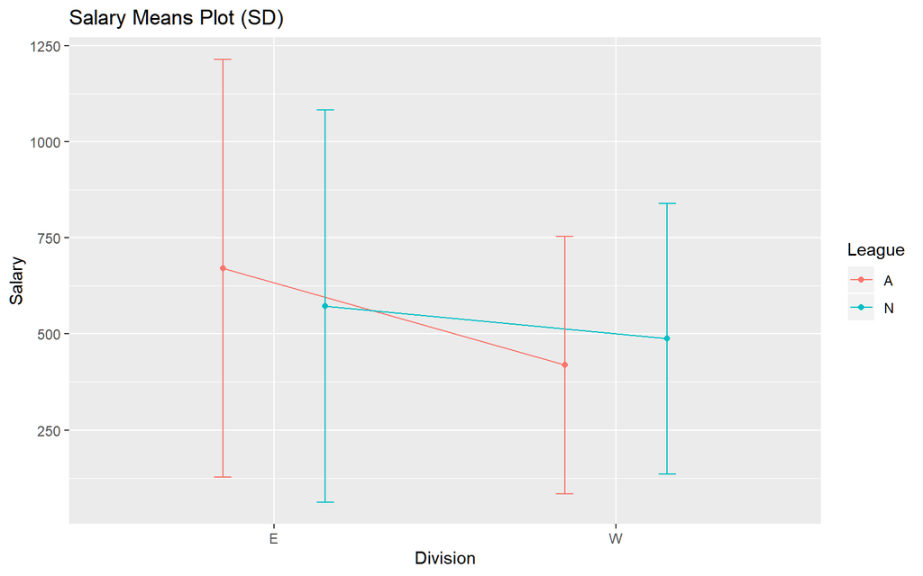

```r
ggplot(sumstats, aes(x = Division, y = Mean, group = League, colour = League)) +
    ylab("Salary") + geom_line(position = position_dodge(0.6)) + geom_point(position = position_dodge(0.6)) +
    geom_errorbar(aes(ymin = Mean - SD, ymax = Mean + SD), width = 0.1, position = position_dodge(0.6)) +
    labs(title = "Salary Means Plot (SD)")
```

The SD bars largely overlap, variance seems difference E vs W but not A vs N. Bars not parallel.

### Fit Full Model

```r
library(car)
model.fit <- aov(Salary ~ League + Division + League:Division, data = hitters)
Anova(model.fit, type = 3)
```

```
Anova Table (Type III tests)

Response: Salary
                  Sum Sq  Df  F value    Pr(>F)
(Intercept)     30602661   1 155.7995 < 2.2e-16 ***
League            311985   1   1.5883 0.2086990
Division         2210214   1  11.2523 0.0009143 ***
League:Division   457684   1   2.3301 0.1281148
Residuals       50873638 259
---
Signif. codes:  0 '***' 0.001 '**' 0.01 '*' 0.05 '.' 0.1 ' ' 1
```

It seems like only Division is significant, not League or the interaction

### Diagnostics

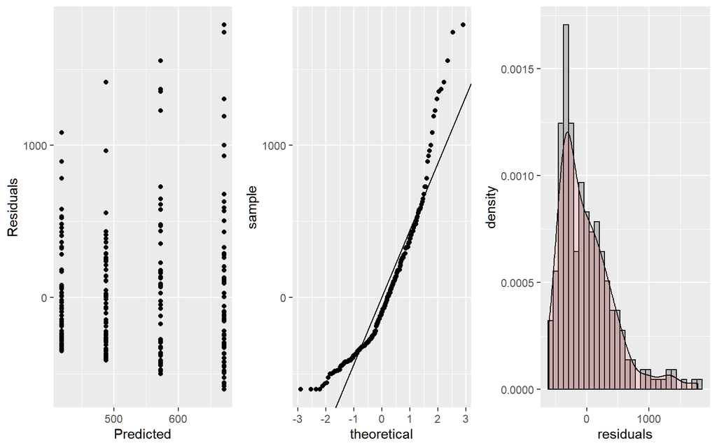

```r
library(gridExtra)
myfits <- data.frame(fitted.values = model.fit$fitted.values, residuals = model.fit$residuals)

# Residual vs Fitted
plot1 <- ggplot(myfits, aes(x = fitted.values, y = residuals)) + ylab("Residuals") +
    xlab("Predicted") + geom_point()

# QQ plot of residuals #Note the diagonal abline is only good for qqplots of
# normal data.
plot2 <- ggplot(myfits, aes(sample = residuals)) + stat_qq() + geom_abline(intercept = mean(myfits$residuals),
    slope = sd(myfits$residuals))

# Histogram of residuals
plot3 <- ggplot(myfits, aes(x = residuals)) + geom_histogram(aes(y = ..density..),
    color = "black", fill = "gray") + geom_density(alpha = 0.1, fill = "red")

grid.arrange(plot1, plot2, plot3, ncol = 3)
```

The residuals are non normal and cone shaped. A transformation of Salary seems to be required. I will re-run with a log transform.

### Fit Full Model

```r
library(car)
model.fit <- aov(logSalary ~ Division + League + Division:League, data = hitters)
Anova(model.fit, type = 3)
```

```
Anova Table (Type III tests)

Response: logSalary
                 Sum Sq  Df   F value    Pr(>F)
(Intercept)     2586.52   1 3354.0999 < 2.2e-16 ***
Division           7.34   1    9.5173  0.002256 **
League             1.57   1    2.0336  0.155057
Division:League    2.75   1    3.5643  0.060154 .
Residuals        199.73 259
---
Signif. codes:  0 '***' 0.001 '**' 0.01 '*' 0.05 '.' 0.1 ' ' 1
```

```r
model.fit <- aov(logSalary ~ League + Division + League:Division, data = hitters)
Anova(model.fit, type = 3)
```

```
Anova Table (Type III tests)

Response: logSalary
                 Sum Sq  Df   F value    Pr(>F)
(Intercept)     2586.52   1 3354.0999 < 2.2e-16 ***
League             1.57   1    2.0336  0.155057
Division           7.34   1    9.5173  0.002256 **
League:Division    2.75   1    3.5643  0.060154 .
Residuals        199.73 259
---
Signif. codes:  0 '***' 0.001 '**' 0.01 '*' 0.05 '.' 0.1 ' ' 1
```

Same as pre transform, It seems like only Division is significant, not League or the interaction

### Diagnostics

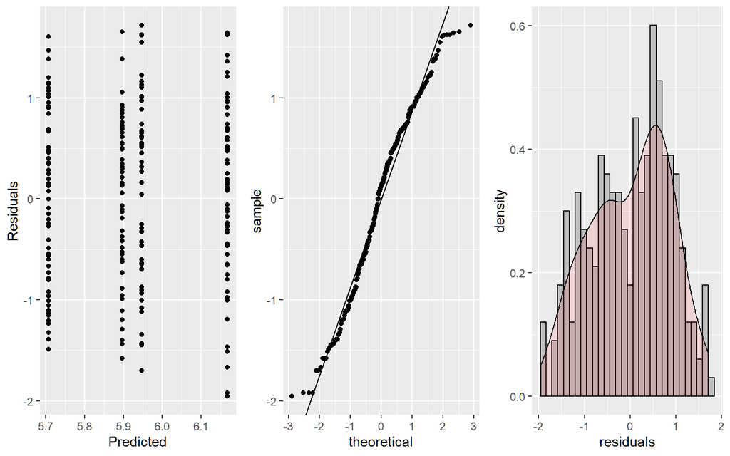

```r
library(gridExtra)
myfits <- data.frame(fitted.values = model.fit$fitted.values, residuals = model.fit$residuals)

# Residual vs Fitted
plot1 <- ggplot(myfits, aes(x = fitted.values, y = residuals)) + ylab("Residuals") +
    xlab("Predicted") + geom_point()

# QQ plot of residuals #Note the diagonal abline is only good for qqplots of
# normal data.
plot2 <- ggplot(myfits, aes(sample = residuals)) + stat_qq() + geom_abline(intercept = mean(myfits$residuals),
    slope = sd(myfits$residuals))

# Histogram of residuals
plot3 <- ggplot(myfits, aes(x = residuals)) + geom_histogram(aes(y = ..density..),
    color = "black", fill = "gray") + geom_density(alpha = 0.1, fill = "red")

grid.arrange(plot1, plot2, plot3, ncol = 3)
```

### Testing

I think we only need to test division since it was the only signficant factor. Running both for kicks.

```r
TukeyHSD(model.fit, "Division", conf.level = 0.95)
```

```
  Tukey multiple comparisons of means
    95% family-wise confidence level

Fit: aov(formula = logSalary ~ League + Division + League:Division, data = hitters)

$Division
          diff     lwr         upr     p adj
W-E -0.2665039 -0.4798 -0.05320784 0.0145322
```

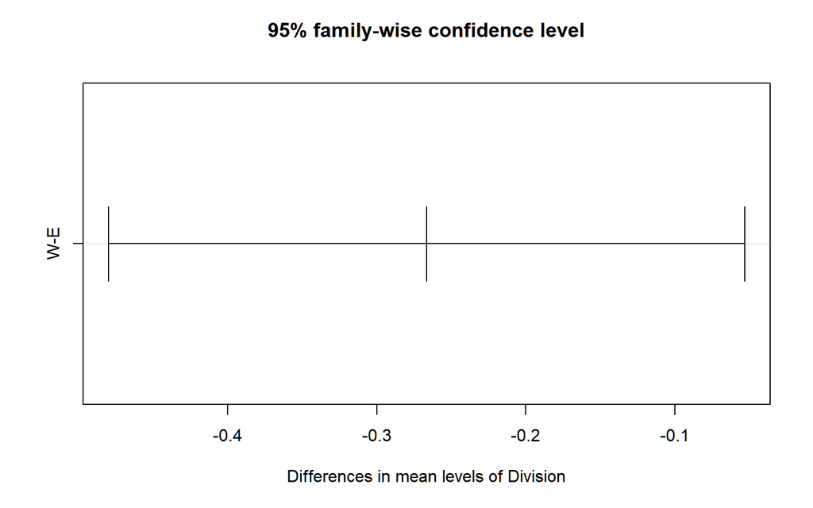

```r
plot(TukeyHSD(model.fit, "Division", conf.level = 0.95))
```

```r
TukeyHSD(model.fit, "League:Division", conf.level = 0.95)
```

```
  Tukey multiple comparisons of means
    95% family-wise confidence level

Fit: aov(formula = logSalary ~ League + Division + League:Division, data = hitters)

$`League:Division`
               diff        lwr         upr     p adj
N:E-A:E -0.22084160 -0.6212824  0.17959919 0.4842307
A:W-A:E -0.45967382 -0.8449628 -0.07438483 0.0120230
N:W-A:E -0.27085697 -0.6679331  0.12621913 0.2932266
A:W-N:E -0.23883222 -0.6352524  0.15758791 0.4046603
N:W-N:E -0.05001537 -0.4579011  0.35787032 0.9889454
N:W-A:W  0.18881685 -0.2042042  0.58183787 0.6005412
```

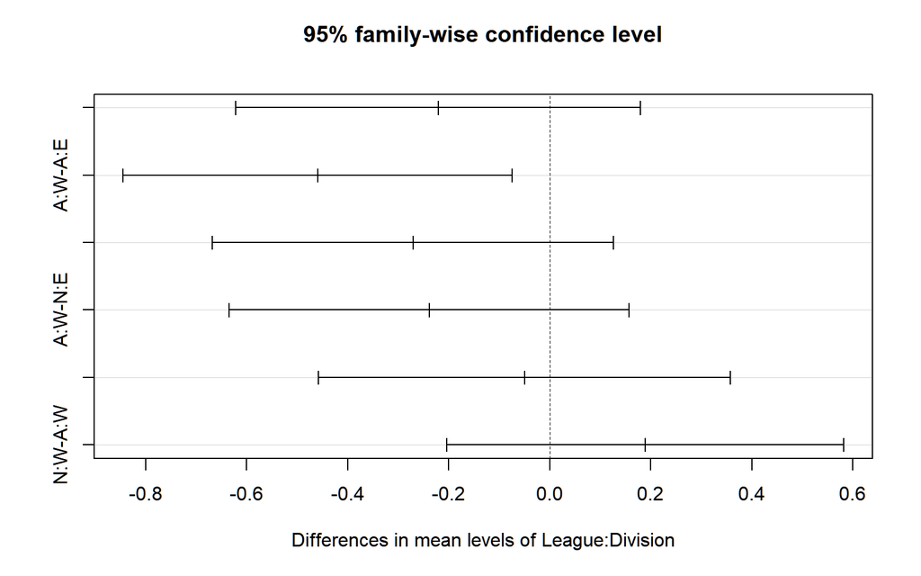

```r
plot(TukeyHSD(model.fit, "League:Division", conf.level = 0.95))
```

William Arnost, Dan Crouthamel

2019-09-29